# Validation of the ozone exposure

- Show All Code
- Hide All Code
- View Source

Station inputs, interpolation model and municipal series · Heatwaves, ozone and mortality in Santiago, 2009-2020

Author

Amaru Agüero Jiménez

Published

November 23, 2026

## 1 What is validated

The ozone exposure of the study is a daily value per municipality, interpolated from the monitoring stations of the SINCA network. Three things can go wrong on the way from the monitors to that value, and each is examined here:

A. **The station inputs.** Are the station series that feed the interpolation faithful to the measurements? B. **The interpolation model.** How well do inverse distance weighting (IDW) and ordinary kriging predict ozone at a place without a monitor? C. **The municipal series.** How much do the delivered series differ from series rebuilt from the measurements, in particular on high-ozone days?

A last section compares the series with an independent source, the CAMS reanalysis, which assimilates satellite ozone retrievals.

The delivered series comes from `pollution-interpolation-kriging-idw`. Its station inputs are hourly SINCA records trimmed at their 1st and 99th percentiles, averaged over the day when at least 12 hours are valid, and completed by imputation. Its interpolation uses IDW (power 2, at most 5 stations within 15 km) and ordinary kriging with a variogram fitted every day. The validation uses the hourly SINCA records as published, with the validation status of every record, for the 11 ozone stations of the Metropolitan Region.

**Code/12_ozone_station_series.R (station series and rebuilt municipal series)**

```r
# 12_ozone_station_series.R
# Ozone at the monitoring stations from the hourly SINCA records, and a
# municipal series rebuilt from them with the data author's interpolation.
#
# Why: the delivered municipal series (script 11) is a 24-hour mean computed
# after trimming the hourly values at their 1st and 99th percentiles and
# filling gaps by imputation. The analysis plan names the daily maximum 8-hour
# mean (MDA8). This script rebuilds both metrics from the hourly records as
# published by SINCA, with no trimming and no imputation, and interpolates
# them with the same model and parameters. Only the hourly records with the
# statuses accepted in the configuration are used.
#
# Inputs
#   inputs$sinca_hourly_dir          hourly ozone by station (ppb)
#   inputs$station_series            station coordinates used by the data author
#   inputs$interpolation_locations   one target point per municipality
# Outputs
#   Data/Derived/ozone_station_daily.csv       station-day: mean24, mda8, valid hours
#   Data/Derived/ozone_rebuilt_municipal.csv   municipality-day: o3obs_* (24-hour
#                                              mean) and o3mda8_* (MDA8)
#   Output/Tables/ozone_station_hourly_status.csv
#   Output/Tables/ozone_rebuilt_qc.csv

suppressPackageStartupMessages({
  library(sf)
  library(sp)
  library(gstat)
  library(automap)
})
source(here::here("Code", "00_setup.R"))
source(here::here("Code", "01_functions.R"))

municipalities <- study_municipalities()
params <- get_param("interpolation")
series_rules <- get_param("station_series")
stopifnot(get_param("air_pollution", "negative_values") == "set_missing")
lag_buffer <- max(unlist(get_param("design", "lags_days")))
keep_dates <- study_dates(buffer_days = lag_buffer)

# ---- 1. Stations and target points ------------------------------------------

station_codes <- fread(here::here(series_rules$stations_file), encoding = "UTF-8")
author <- new.env()
load(input_path("station_series"), envir = author)
load(input_path("interpolation_locations"), envir = author)

station_points <- author$imputed_series[!duplicated(author$imputed_series$station), "station"]
station_points <- merge(station_points, station_codes, by = "station")
stopifnot(nrow(station_points) == nrow(station_codes),
          sf::st_crs(station_points)$epsg == params$crs_epsg)

targets <- author$interpol
stopifnot(setequal(targets$comuna, municipalities$name),
          sf::st_crs(targets)$epsg == params$crs_epsg)

# ---- 2. Daily series by station ---------------------------------------------

read_station <- function(i) {
  file <- file.path(input_path("sinca_hourly_dir"),
                    sprintf(series_rules$hourly_file_pattern, station_codes$sinca_id[i]))
  if (!file.exists(file)) stop("Hourly file not found: ", file, call. = FALSE)
  hourly <- read_sinca_hourly(file, accepted_status = unlist(series_rules$accepted_status))
  daily <- daily_from_hourly(
    hourly,
    min_hours = series_rules$min_valid_hours_day,
    mda8_min_hours = series_rules$mda8_min_hours_window,
    mda8_min_windows = series_rules$mda8_min_windows_day
  )
  status <- hourly[date %in% keep_dates, .(hours = .N), by = status]
  list(
    daily = cbind(station_codes[i], daily[date %in% keep_dates]),
    status = cbind(station_codes[i], status)
  )
}
stations <- lapply(seq_len(nrow(station_codes)), read_station)
station_daily <- rbindlist(lapply(stations, `[[`, "daily"))
hourly_status <- rbindlist(lapply(stations, `[[`, "status"))
hourly_status[is.na(status), status := "no_record"]

setorder(station_daily, station, date)
fwrite(station_daily, file.path(dir_derived, "ozone_station_daily.csv"))
fwrite(dcast(hourly_status, sinca_id + station ~ status, value.var = "hours", fill = 0),
       file.path(dir_tables, "ozone_station_hourly_status.csv"))

# ---- 3. Municipal series rebuilt with the same interpolation ----------------

setkey(station_daily, date)
metric_prefix <- c(mean24 = "o3obs", mda8 = "o3mda8")

rebuild_day <- function(day) {
  out <- data.table(municipality = targets$comuna, date = day)
  for (metric in names(metric_prefix)) {
    prefix <- metric_prefix[[metric]]
    values <- station_daily[.(day)][!is.na(get(metric)), .(station, value = get(metric))]
    out[, (paste0(prefix, "_n_stations")) := nrow(values)]
    if (nrow(values) >= params$ok_min_stations) {
      day_stations <- merge(station_points, values, by = "station")
      result <- with_warnings(interpolate_day(day_stations, targets, "value", params))
      out[, (paste0(prefix, c("_idw", "_ok", "_ok_var"))) := result$value[, .(idw, ok, ok_var)]]
      out[, (paste0(prefix, "_ok_warning")) := length(result$warnings) > 0]
      out[, (paste0(prefix, "_ok_failed")) := !is.na(result$value$ok_error[1])]
    } else {
      out[, (paste0(prefix, c("_idw", "_ok", "_ok_var"))) := NA_real_]
      out[, (paste0(prefix, "_ok_warning")) := NA]
      out[, (paste0(prefix, "_ok_failed")) := NA]
    }
  }
  out
}
# The result does not depend on the number of cores.
rebuilt_days <- parallel::mclapply(as.list(keep_dates), rebuild_day,
                                   mc.cores = parallel::detectCores())
failed <- vapply(rebuilt_days, inherits, logical(1), what = "try-error")
if (any(failed)) {
  stop("Interpolation failed on ", format(keep_dates[which(failed)[1]]), ": ",
       rebuilt_days[[which(failed)[1]]], call. = FALSE)
}
rebuilt <- rbindlist(rebuilt_days)
stopifnot(nrow(rebuilt) == nrow(municipalities) * length(keep_dates))

# Same rule as the delivered series for kriging values below zero
qc <- list()
for (prefix in metric_prefix) {
  for (m in c("idw", "ok")) {
    col <- paste0(prefix, "_", m)
    negative <- !is.na(rebuilt[[col]]) & rebuilt[[col]] < 0
    qc[[length(qc) + 1]] <- data.table(
      series = prefix, method = m, rows = nrow(rebuilt),
      missing = sum(is.na(rebuilt[[col]])), negative_set_missing = sum(negative),
      days_below_min_stations = rebuilt[get(paste0(prefix, "_n_stations")) < params$ok_min_stations,
                                        uniqueN(date)],
      days_with_kriging_warning = rebuilt[get(paste0(prefix, "_ok_warning")) == TRUE, uniqueN(date)],
      days_variogram_not_fitted = rebuilt[get(paste0(prefix, "_ok_failed")) == TRUE, uniqueN(date)]
    )
    set(rebuilt, which(negative), col, NA_real_)
    if (m == "ok") set(rebuilt, which(negative), paste0(prefix, "_ok_var"), NA_real_)
  }
}
fwrite(rbindlist(qc), file.path(dir_tables, "ozone_rebuilt_qc.csv"))

rebuilt <- merge(municipalities, rebuilt, by.x = "name", by.y = "municipality")
setnames(rebuilt, c("code", "name"), c("com", "municipality"))
setcolorder(rebuilt, c("com", "municipality", "date"))
setorder(rebuilt, com, date)
fwrite(rebuilt, file.path(dir_derived, "ozone_rebuilt_municipal.csv"))

message("ozone_station_daily.csv: ", nrow(station_daily), " station-days; ",
        "ozone_rebuilt_municipal.csv: ", nrow(rebuilt), " rows")
print(rbindlist(qc))
```

**Code/14_interpolation_validation.R (leave-one-station-out predictions)**

```r
# 14_interpolation_validation.R
# Leave-one-station-out cross-validation of the ozone interpolation.
#
# For every warm-season day of the study years each station is removed in
# turn, the data author's model (IDW and ordinary kriging, same parameters)
# is fitted to the remaining stations, and the removed station is predicted.
# The observed values are the validated 24-hour mean and MDA8 of script 12.
#
# This is the slow step of the pipeline (one variogram fit per day, station
# and metric: about 75 minutes on two cores). It only writes the predictions;
# script 17 turns them into tables.
#
# Inputs
#   Data/Derived/ozone_station_daily.csv   (script 12)
#   inputs$station_series                  station coordinates
# Output
#   Data/Derived/validation_loso_predictions.csv   one row per day, metric and
#                                                  station left out

suppressPackageStartupMessages({
  library(sf)
  library(sp)
  library(gstat)
  library(automap)
})
source(here::here("Code", "00_setup.R"))
source(here::here("Code", "01_functions.R"))

params <- get_param("interpolation")
study_years <- get_param("study", "years")
warm_months <- get_param("study", "warm_season_months")

station_daily <- fread(derived_path("ozone_station_daily.csv"), encoding = "UTF-8")
station_daily[, date := as.Date(date)]
station_daily <- station_daily[year(date) >= study_years[1] & year(date) <= study_years[2]]
station_daily[, warm_season := is_warm_season(date, warm_months)]

author <- new.env()
load(input_path("station_series"), envir = author)
station_points <- author$imputed_series[!duplicated(author$imputed_series$station), "station"]
station_points <- station_points[station_points$station %in% station_daily$station, ]

cv_days <- sort(unique(station_daily[warm_season == TRUE, date]))
setkey(station_daily, date)

loso_day <- function(day) {
  results <- list()
  for (metric in c("mean24", "mda8")) {
    values <- station_daily[.(day)][!is.na(get(metric)), .(station, value = get(metric))]
    # The fit needs ok_min_stations after one station is removed
    if (nrow(values) - 1 < params$ok_min_stations) next
    points <- merge(station_points, values, by = "station")
    for (i in seq_len(nrow(points))) {
      fit <- with_warnings(interpolate_day(points[-i, ], points[i, ], "value", params))
      results[[length(results) + 1]] <- data.table(
        date = day, metric = metric, station = points$station[i],
        observed = points$value[i], n_fit_stations = nrow(points) - 1,
        fit$value, ok_warning = length(fit$warnings) > 0
      )
    }
  }
  rbindlist(results)
}
# The result does not depend on the number of cores.
loso_days <- parallel::mclapply(as.list(cv_days), loso_day, mc.cores = parallel::detectCores())
failed <- vapply(loso_days, inherits, logical(1), what = "try-error")
if (any(failed)) {
  stop("Cross-validation failed on ", format(cv_days[which(failed)[1]]), ": ",
       loso_days[[which(failed)[1]]], call. = FALSE)
}
loso <- rbindlist(loso_days)
stopifnot(nrow(loso) > 0)
fwrite(loso, file.path(dir_derived, "validation_loso_predictions.csv"))

message("validation_loso_predictions.csv: ", nrow(loso), " predictions on ", length(cv_days), " days")
```

**Code/17_validation_summary.R (tables of the three validations)**

```r
# 17_validation_summary.R
# Validation of the ozone exposure: tables.
#
# Three questions
#   A. Station inputs: how do the station series used by the data author
#      compare with the daily means computed from the validated hourly SINCA
#      records?
#   B. Interpolation model: how well do IDW and ordinary kriging predict a
#      station left out of the fit (predictions of script 14)?
#   C. Municipal series: how does the delivered series compare with the one
#      rebuilt from the validated records with the same model?
#
# Inputs
#   Data/Derived/ozone_station_daily.csv            (script 12)
#   Data/Derived/exposure_2009_2020.csv             (script 13)
#   Data/Derived/validation_loso_predictions.csv    (script 14)
#   inputs$station_series                           the data author's station series
# Outputs, all in Output/Tables
#   validation_inputs_by_station.csv   validation_inputs_by_level.csv
#   validation_loso_overall.csv        validation_loso_common.csv
#   validation_loso_by_station.csv     validation_loso_high_ozone.csv
#   validation_reproduction.csv        validation_municipal_by_level.csv
#   validation_municipal_flags.csv

source(here::here("Code", "00_setup.R"))
source(here::here("Code", "01_functions.R"))

params <- get_param("interpolation")
study_years <- get_param("study", "years")
warm_months <- get_param("study", "warm_season_months")
cutoffs <- unlist(get_param("air_pollution", "ozone_percentile_cutoffs"))
z <- stats::qnorm(1 - (1 - params$conf_level) / 2)

station_daily <- fread(derived_path("ozone_station_daily.csv"), encoding = "UTF-8")
station_daily[, date := as.Date(date)]
station_daily <- station_daily[year(date) >= study_years[1] & year(date) <= study_years[2]]

author <- new.env()
load(input_path("station_series"), envir = author)

# ---- A. Station inputs ------------------------------------------------------

author_series <- as.data.table(sf::st_drop_geometry(author$imputed_series))[
  , .(station, date, author_o3 = daily_o3)]
inputs <- merge(station_daily, author_series, by = c("station", "date"), all = TRUE)
inputs <- inputs[!is.na(author_o3) | !is.na(mean24)]
inputs[, warm_season := is_warm_season(date, warm_months)]
inputs[, status := fcase(
  !is.na(author_o3) & is.na(mean24), "no validated daily mean",
  is.na(author_o3) & !is.na(mean24), "observed, absent from the author's series",
  abs(author_o3 - mean24) < 0.005, "identical",
  default = "modified"
)]

inputs_summary <- function(dt) {
  dt[, .(
    station_days = .N,
    identical_pct = 100 * mean(status == "identical"),
    modified_pct = 100 * mean(status == "modified"),
    no_validated_mean_pct = 100 * mean(status == "no validated daily mean"),
    absent_pct = 100 * mean(status == "observed, absent from the author's series"),
    mean_observed = mean(mean24[status %in% c("identical", "modified")]),
    mean_author_same_days = mean(author_o3[status %in% c("identical", "modified")]),
    mean_change_when_modified = mean((author_o3 - mean24)[status == "modified"])
  ), by = station]
}
by_station <- rbind(
  cbind(period = "all days", inputs_summary(inputs)),
  cbind(period = "warm season", inputs_summary(inputs[warm_season == TRUE]))
)
total <- rbind(
  cbind(period = "all days", inputs_summary(copy(inputs)[, station := "All stations"])),
  cbind(period = "warm season",
        inputs_summary(copy(inputs[warm_season == TRUE])[, station := "All stations"]))
)
fwrite(rbind(by_station, total), file.path(dir_tables, "validation_inputs_by_station.csv"))

# Difference by ozone level: warm-season station-days with both values,
# grouped by tenths of the observed 24-hour mean
both <- inputs[warm_season == TRUE & status %in% c("identical", "modified")]
both[, level := cut(mean24, stats::quantile(mean24, 0:10 / 10), include.lowest = TRUE,
                    labels = paste0("D", 1:10))]
by_level <- both[, .(
  station_days = .N, observed_mean24 = mean(mean24), observed_mda8 = mean(mda8, na.rm = TRUE),
  author_mean = mean(author_o3), difference = mean(author_o3 - mean24),
  modified_pct = 100 * mean(status == "modified")
), keyby = level]
fwrite(by_level, file.path(dir_tables, "validation_inputs_by_level.csv"))

# ---- B. Leave-one-station-out cross-validation ------------------------------

loso <- fread(derived_path("validation_loso_predictions.csv"), encoding = "UTF-8")
loso[, date := as.Date(date)]

loso_long <- melt(loso, id.vars = c("date", "metric", "station", "observed", "ok_var"),
                  measure.vars = c("idw", "ok"), variable.name = "method",
                  value.name = "predicted")
# All station-days that each method could predict
overall <- loso_long[, validation_metrics(observed, predicted), by = .(metric, method)]
# Share of station-days with no prediction (IDW: no station within the search radius)
overall <- merge(overall, loso_long[, .(not_predicted_pct = 100 * mean(is.na(predicted))),
                                    by = .(metric, method)], by = c("metric", "method"))
# Share of observed values inside the nominal kriging interval
coverage <- loso[!is.na(ok), .(method = "ok", interval_coverage_pct =
  100 * mean(abs(observed - ok) <= z * sqrt(ok_var))), by = metric]
overall <- merge(overall, coverage, by = c("metric", "method"), all.x = TRUE)
fwrite(overall, file.path(dir_tables, "validation_loso_overall.csv"))

# The two methods on the same station-days: IDW gives no value when no station
# lies within its search radius, kriging always does, so the sets above differ
common <- loso[!is.na(idw) & !is.na(ok)]
common_long <- melt(common, id.vars = c("date", "metric", "station", "observed"),
                    measure.vars = c("idw", "ok"), variable.name = "method",
                    value.name = "predicted")
fwrite(common_long[, validation_metrics(observed, predicted), by = .(metric, method)],
       file.path(dir_tables, "validation_loso_common.csv"))

by_station_cv <- loso_long[, validation_metrics(observed, predicted),
                           by = .(metric, method, station)]
fwrite(by_station_cv, file.path(dir_tables, "validation_loso_by_station.csv"))

# High-ozone days: observed and predicted values are each classified against
# their own station percentile, as the exposure categories are built
high <- rbindlist(lapply(cutoffs, function(p) {
  d <- loso_long[!is.na(predicted)]
  d[, `:=`(observed_high = as.integer(observed > stats::quantile(observed, p / 100)),
           predicted_high = as.integer(predicted > stats::quantile(predicted, p / 100))),
    by = .(metric, method, station)]
  cbind(percentile = p,
        d[, classification_agreement(observed_high, predicted_high), by = .(metric, method)])
}))
fwrite(high, file.path(dir_tables, "validation_loso_high_ozone.csv"))

# ---- C. Delivered against rebuilt municipal series --------------------------

exposure <- fread(derived_path("exposure_2009_2020.csv"), encoding = "UTF-8")
exposure[, date := as.Date(date)]
exposure <- exposure[in_study_period == TRUE & warm_season == TRUE]

# Reproduction: on the days when every station value of the author's series
# equals the validated 24-hour mean, the rebuilt municipal series should equal
# the delivered one if this project runs the same interpolation.
day_status <- inputs[, .(all_identical = all(status == "identical")), by = date]
same_input_days <- day_status[all_identical == TRUE, date]
same <- exposure[date %in% same_input_days]
reproduction <- rbindlist(lapply(c("idw", "ok"), function(m) {
  difference <- abs(same[[paste0("o3_", m)]] - same[[paste0("o3obs_", m)]])
  data.table(method = m, days = uniqueN(same$date), municipality_days = sum(!is.na(difference)),
             within_0.001_ppb_pct = 100 * mean(difference < 1e-3, na.rm = TRUE),
             median_abs_difference = stats::median(difference, na.rm = TRUE),
             max_abs_difference = max(difference, na.rm = TRUE))
}))
fwrite(reproduction, file.path(dir_tables, "validation_reproduction.csv"))

municipal_level <- rbindlist(lapply(c("idw", "ok"), function(m) {
  d <- exposure[, .(com, delivered = get(paste0("o3_", m)), rebuilt = get(paste0("o3obs_", m)),
                    mda8 = get(paste0("o3mda8_", m)))]
  d <- d[!is.na(delivered) & !is.na(rebuilt)]
  d[, level := cut(rebuilt, stats::quantile(rebuilt, 0:10 / 10), include.lowest = TRUE,
                   labels = paste0("D", 1:10))]
  cbind(method = m, d[, .(
    municipality_days = .N, rebuilt_mean24 = mean(rebuilt), delivered_mean24 = mean(delivered),
    difference = mean(delivered - rebuilt), rebuilt_mda8 = mean(mda8, na.rm = TRUE)
  ), keyby = level])
}))
fwrite(municipal_level, file.path(dir_tables, "validation_municipal_by_level.csv"))

# Agreement of the high-ozone flags between series (reference: rebuilt)
flag_pairs <- list(c("o3obs", "o3"), c("o3mda8", "o3"), c("o3mda8", "o3obs"))
municipal_flags <- rbindlist(lapply(flag_pairs, function(pair) {
  rbindlist(lapply(c("idw", "ok"), function(m) rbindlist(lapply(cutoffs, function(p) {
    reference <- exposure[[paste0(pair[1], "_", m, "_gt_p", p)]]
    test <- exposure[[paste0(pair[2], "_", m, "_gt_p", p)]]
    values <- exposure[, .(a = get(paste0(pair[1], "_", m)), b = get(paste0(pair[2], "_", m)))]
    cbind(reference = pair[1], compared = pair[2], method = m, percentile = p,
          classification_agreement(reference, test),
          pearson_r = values[!is.na(a) & !is.na(b), cor(a, b)])
  }))))
}))
fwrite(municipal_flags, file.path(dir_tables, "validation_municipal_flags.csv"))

print(overall)
```

**Code/16_reanalysis_comparison.R (comparison with CAMS)**

```r
# 16_reanalysis_comparison.R
# Ozone of the municipal series against the CAMS global reanalysis (EAC4).
#
# CAMS EAC4 assimilates satellite retrievals of ozone into a global chemistry
# model. Its cells measure 0.75 degrees (about 70 by 83 km here), so the whole
# study area falls in two cells: the reanalysis cannot say anything about
# differences between municipalities. It is an independent source for the
# day-to-day course of ozone over the city, which is what this script uses.
#
# Inputs
#   inputs$cams_eac4_dir                    monthly files of 3-hourly values by cell
#   Data/Derived/interpolation_points.csv   (script 15)
#   Data/Derived/exposure_2009_2020.csv     (script 13)
# Outputs
#   Data/Derived/cams_ozone_daily.csv            cell-day: daily mean and afternoon value (ppb)
#   Output/Tables/validation_cams_cells.csv      cells used and municipalities in each
#   Output/Tables/validation_cams_correlation.csv
#
# Correlations are computed for the city-wide daily mean (the mean of the 33
# municipalities), on the warm-season days of the study years, in two forms:
# on the daily values, and on the anomalies from the mean of each calendar
# month, which removes the seasonal cycle shared by any two ozone series.

suppressPackageStartupMessages({
  library(sf)
  library(ncdf4)
})
source(here::here("Code", "00_setup.R"))
source(here::here("Code", "01_functions.R"))

rules <- get_param("reanalysis")
study_years <- get_param("study", "years")
warm_months <- get_param("study", "warm_season_months")
# Mass mixing ratio (kg/kg) to volume mixing ratio (ppb): molar masses of dry
# air (28.9644 g/mol) and ozone (47.9982 g/mol)
kgkg_to_ppb <- 28.9644 / 47.9982 * 1e9

# ---- 1. Cells that contain the municipal target points ----------------------

targets <- fread(derived_path("interpolation_points.csv"), encoding = "UTF-8")
lonlat <- sf::st_coordinates(sf::st_transform(
  sf::st_as_sf(targets, coords = c("x", "y"), crs = get_param("interpolation", "crs_epsg")), 4326
))
targets[, `:=`(lon = lonlat[, 1], lat = lonlat[, 2])]

files <- list.files(input_path("cams_eac4_dir"), pattern = "\\.nc$", full.names = TRUE)
stopifnot(length(files) > 0)
first <- ncdf4::nc_open(files[1])
cells <- data.table(pixel = seq_along(ncdf4::ncvar_get(first, "pixel_id")),
                    pixel_id = as.vector(ncdf4::ncvar_get(first, "pixel_id")),
                    cell_lat = as.vector(ncdf4::ncvar_get(first, "latitude")),
                    cell_lon = as.vector(ncdf4::ncvar_get(first, "longitude")))
stopifnot(ncdf4::ncatt_get(first, "o3", "units")$value == "kg kg**-1")
ncdf4::nc_close(first)

half <- rules$cell_size_degrees / 2
targets[, pixel_id := vapply(seq_len(.N), function(i) {
  hit <- cells[abs(cell_lat - lat[i]) <= half & abs(cell_lon - lon[i]) <= half]
  stopifnot(nrow(hit) == 1)
  hit$pixel_id
}, numeric(1))]
used <- cells[pixel_id %in% targets$pixel_id]
fwrite(merge(used[, .(pixel_id, cell_lat, cell_lon)],
             targets[, .(municipalities = .N, names = paste(municipality, collapse = "; ")), by = pixel_id],
             by = "pixel_id"),
       file.path(dir_tables, "validation_cams_cells.csv"))

# ---- 2. Daily values by cell, in local time ---------------------------------

read_month <- function(file) {
  nc <- ncdf4::nc_open(file)
  on.exit(ncdf4::nc_close(nc))
  ids <- as.vector(ncdf4::ncvar_get(nc, "pixel_id"))
  stopifnot(identical(ids, cells$pixel_id))
  time_units <- ncdf4::ncatt_get(nc, "time", "units")$value
  origin <- as.POSIXct(sub("^[a-z]+ since ", "", time_units), tz = "UTC")
  step <- switch(sub(" since.*$", "", time_units), hours = 3600, seconds = 1, days = 86400)
  stopifnot(!is.null(step))
  utc <- origin + ncdf4::ncvar_get(nc, "time") * step
  ozone <- ncdf4::ncvar_get(nc, "o3")                    # pixel x time
  stopifnot(identical(dim(ozone), c(length(ids), length(utc))))
  rbindlist(lapply(used$pixel, function(p) {
    data.table(pixel_id = ids[p], utc = utc, o3_ppb = ozone[p, ] * kgkg_to_ppb)
  }))
}
cams <- rbindlist(lapply(files, read_month))
stopifnot(anyDuplicated(cams[, .(pixel_id, utc)]) == 0, !anyNA(cams$o3_ppb))
cams[, local := utc + rules$utc_offset_hours * 3600]
cams[, `:=`(date = as.Date(format(local, "%Y-%m-%d", tz = "UTC")),
            hour = as.integer(format(local, "%H", tz = "UTC")))]
afternoon <- unlist(rules$afternoon_local_hours)
stopifnot(all(afternoon %in% unique(cams$hour)))
cams_daily <- cams[, .(
  records = .N,
  cams_mean24 = mean(o3_ppb),
  cams_afternoon = mean(o3_ppb[hour %in% afternoon])
), by = .(pixel_id, date)]
cams_daily <- cams_daily[records == 8]        # complete local days only
fwrite(cams_daily, file.path(dir_derived, "cams_ozone_daily.csv"))

# ---- 3. City-wide daily series and correlations -----------------------------

exposure <- fread(derived_path("exposure_2009_2020.csv"), encoding = "UTF-8")
exposure[, date := as.Date(date)]
exposure <- exposure[in_study_period == TRUE & warm_season == TRUE]
exposure <- merge(exposure, targets[, .(com, pixel_id)], by = "com")
exposure <- merge(exposure, cams_daily, by = c("pixel_id", "date"))
stopifnot(uniqueN(exposure$date) == uniqueN(cams_daily[
  year(date) >= study_years[1] & year(date) <= study_years[2] & month(date) %in% warm_months, date]))

pairs <- data.table(
  series = c("o3_idw", "o3_ok", "o3obs_idw", "o3obs_ok", "o3mda8_idw", "o3mda8_ok"),
  cams = c(rep("cams_mean24", 4), rep("cams_afternoon", 2))
)
city <- exposure[, c(lapply(.SD, mean, na.rm = TRUE)), by = date,
                 .SDcols = c(pairs$series, "cams_mean24", "cams_afternoon")]
city[, month_id := format(date, "%Y-%m")]
correlations <- rbindlist(lapply(seq_len(nrow(pairs)), function(i) {
  d <- city[, .(date, month_id, x = get(pairs$series[i]), y = get(pairs$cams[i]))][!is.na(x)]
  d[, `:=`(x_anomaly = x - mean(x), y_anomaly = y - mean(y)), by = month_id]
  data.table(series = pairs$series[i], cams = pairs$cams[i], days = nrow(d),
             mean_series = mean(d$x), mean_cams = mean(d$y),
             correlation_daily = cor(d$x, d$y),
             correlation_anomalies = cor(d$x_anomaly, d$y_anomaly))
}))
fwrite(correlations, file.path(dir_tables, "validation_cams_correlation.csv"))
fwrite(city[, !"month_id"], file.path(dir_derived, "cams_city_daily.csv"))
print(correlations)
```

## 2 A. Station inputs

The station series published with the interpolation code (2009-2020) are compared, station by station and day by day, with the 24-hour mean computed from the validated hourly records with the same rule of at least 12 valid hours. A station-day is *identical* when the two values agree, *modified* when both exist and differ, and has *no validated daily mean* when the author’s series holds a value that the validated records cannot produce (imputed, or built on records never validated).

```r
kable(by_station[period == "warm season",
                 .(station, station_days, identical_pct, modified_pct, no_validated_mean_pct,
                   mean_observed, mean_author_same_days, mean_change_when_modified)],
      digits = 1, format.args = list(big.mark = ","),
      col.names = c("Station", "Station-days", "Identical (%)", "Modified (%)",
                    "No validated daily mean (%)", "Observed mean (ppb)",
                    "Author's mean, same days (ppb)", "Mean change when modified (ppb)"))
```

Table 1: Author’s station series against the validated hourly records, warm seasons 2009-2020.

| Station | Station-days | Identical (%) | Modified (%) | No validated daily mean (%) | Observed mean (ppb) | Author’s mean, same days (ppb) | Mean change when modified (ppb) |
| --- | --- | --- | --- | --- | --- | --- | --- |
| Cerrillos I | 1,221 | 84.8 | 14.3 | 0.8 | 22.1 | 21.4 | -4.8 |
| Cerro Navia | 1,815 | 86.7 | 7.2 | 6.1 | 20.8 | 20.4 | -4.7 |
| El Bosque | 1,815 | 89.4 | 6.9 | 3.6 | 18.6 | 18.2 | -4.9 |
| Independencia | 1,815 | 78.9 | 13.7 | 7.4 | 17.9 | 17.3 | -4.5 |
| La Florida | 1,815 | 77.9 | 20.9 | 1.3 | 19.8 | 18.6 | -5.9 |
| Las Condes | 1,815 | 36.3 | 60.8 | 2.9 | 25.7 | 20.9 | -7.7 |
| Parque O’Higgins | 1,815 | 71.8 | 17.8 | 10.4 | 21.3 | 20.4 | -4.6 |
| Pudahuel | 1,815 | 83.1 | 4.7 | 12.1 | 19.5 | 19.3 | -3.8 |
| Puente Alto | 1,815 | 76.6 | 15.8 | 7.7 | 22.9 | 22.0 | -5.2 |
| Quilicura I | 1,149 | 86.4 | 8.5 | 5.0 | 21.0 | 20.6 | -4.5 |
| Talagante | 1,815 | 85.9 | 1.9 | 12.2 | 18.6 | 18.5 | -7.0 |
| All stations | 18,705 | 77.5 | 16.0 | 6.5 | 20.7 | 19.7 | -6.0 |

In the warm season 16.0% of the station-days were modified and 6.5% have no validated daily mean. The modifications are not spread evenly: they concentrate on the days with most ozone.

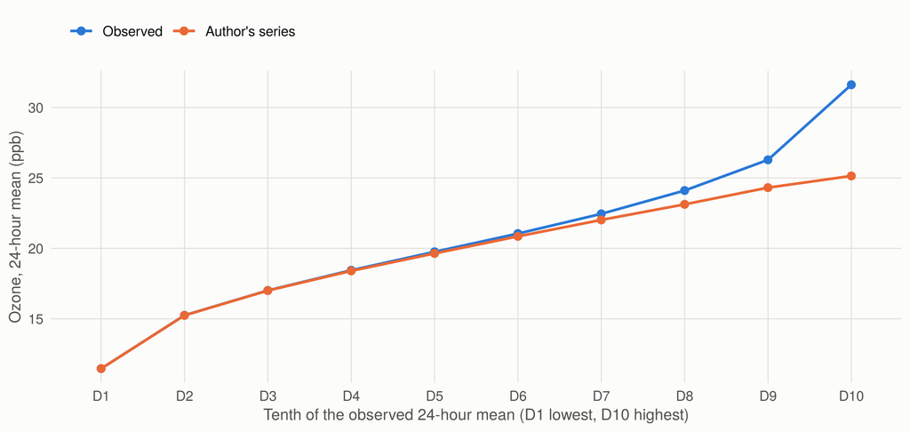

Figure 1: Author’s station series against the observed 24-hour mean, by tenths of the observed value. Warm-season station-days with both values.

```r
level_long <- melt(by_level[, .(level, `Observed` = observed_mean24, `Author's series` = author_mean)],
                   id.vars = "level", variable.name = "series", value.name = "ozone")
level_long[, level := factor(level, levels = paste0("D", 1:10))]
ggplot(level_long, aes(level, ozone, colour = series, group = series)) +
  geom_line(linewidth = 0.8) +
  geom_point(size = 2) +
  scale_colour_manual(values = c("Observed" = "#2a78d6", "Author's series" = "#eb6834")) +
  labs(x = "Tenth of the observed 24-hour mean (D1 lowest, D10 highest)",
       y = "Ozone, 24-hour mean (ppb)", colour = NULL)
```

```r
kable(by_level, digits = 1, format.args = list(big.mark = ","),
      col.names = c("Tenth", "Station-days", "Observed 24-hour mean (ppb)", "Observed MDA8 (ppb)",
                    "Author's mean (ppb)", "Difference (ppb)", "Modified (%)"))
```

Table 2: Values behind the figure, with the observed MDA8 of the same days and the share of modified station-days.

| Tenth | Station-days | Observed 24-hour mean (ppb) | Observed MDA8 (ppb) | Author’s mean (ppb) | Difference (ppb) | Modified (%) |
| --- | --- | --- | --- | --- | --- | --- |
| D1 | 1,763 | 11.5 | 23.6 | 11.5 | 0.0 | 0.1 |
| D2 | 1,746 | 15.3 | 31.0 | 15.2 | 0.0 | 0.3 |
| D3 | 1,736 | 17.0 | 34.2 | 17.0 | 0.0 | 0.5 |
| D4 | 1,753 | 18.4 | 36.8 | 18.4 | 0.0 | 1.9 |
| D5 | 1,744 | 19.8 | 39.3 | 19.6 | -0.1 | 3.6 |
| D6 | 1,748 | 21.0 | 41.6 | 20.9 | -0.2 | 6.5 |
| D7 | 1,760 | 22.5 | 44.6 | 22.0 | -0.4 | 12.2 |
| D8 | 1,757 | 24.1 | 47.9 | 23.1 | -1.0 | 24.9 |
| D9 | 1,729 | 26.3 | 52.0 | 24.3 | -2.0 | 43.4 |
| D10 | 1,747 | 31.6 | 61.3 | 25.1 | -6.5 | 78.1 |

On the tenth of station-days with most ozone the author’s series is 6.5 ppb lower than the measurements (25.1 against 31.6 ppb, a 20% reduction), and 78% of those station-days were modified. This is what trimming the hourly values at their 99th percentile does to ozone: the hours it removes are the afternoon peaks of the hottest days, so the daily mean of exactly those days is pulled down. The trimming flattens the upper tail of the exposure that the study is about.

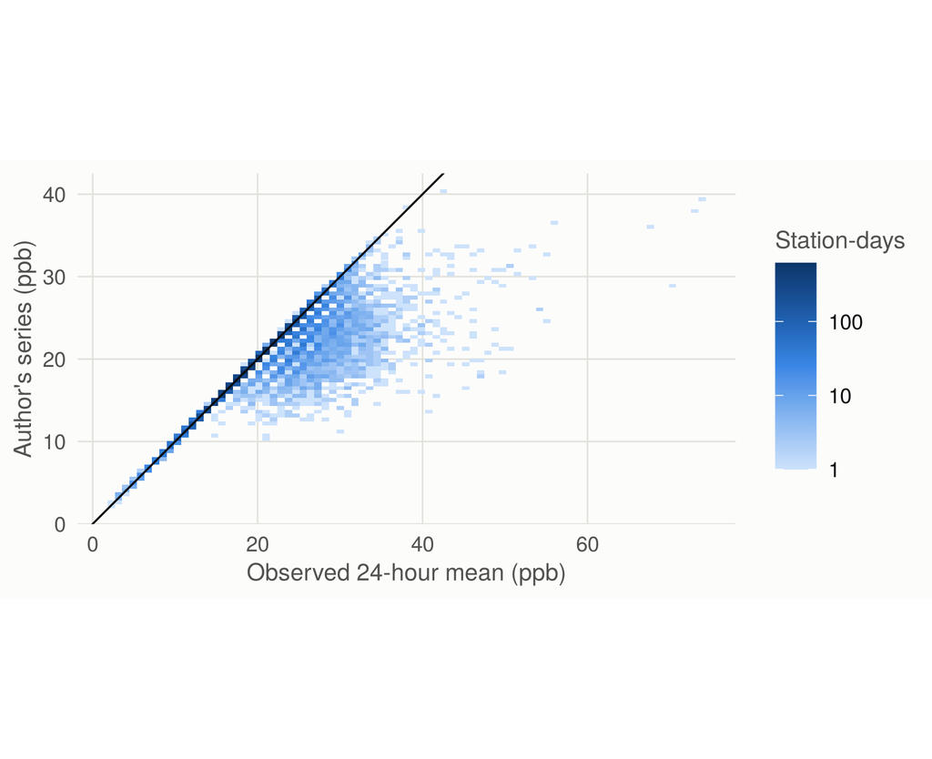

Figure 2: Author’s station series against the observed 24-hour mean, warm-season station-days 2009-2020. The line is equality.

```r
both <- inputs[warm_season == TRUE & !is.na(author_o3) & !is.na(mean24)]
ggplot(both, aes(mean24, author_o3)) +
  geom_bin2d(bins = 80) +
  geom_abline(colour = ink$primary, linewidth = 0.4) +
  scale_fill_magnitude(name = "Station-days", trans = "log10") +
  coord_equal() +
  labs(x = "Observed 24-hour mean (ppb)", y = "Author's series (ppb)") +
  theme(legend.position = "right", legend.justification = "center")
```

### 2.1 Records that were never validated

SINCA marks every hourly record as validated, preliminary or not validated. Most records of the study period are validated, but some station-periods were never validated, and one of them is an evident instrument failure.

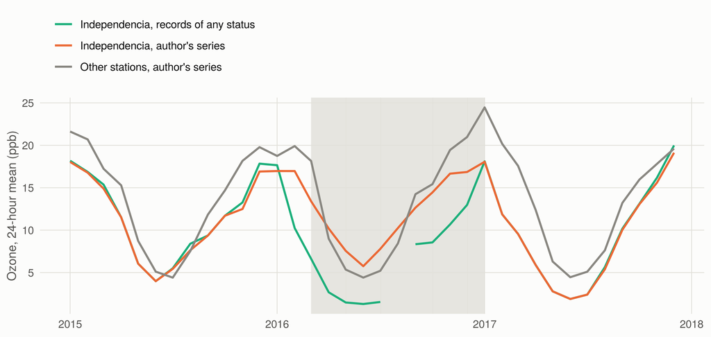

Figure 3: Independencia, 2015-2017, monthly mean of the 24-hour ozone: hourly records of any status, the author’s series, and the mean of the other stations in the author’s series. Shaded: months in which Independencia has no validated record.

```r
rules <- get_param("station_series")
codes <- fread(here::here(rules$stations_file), encoding = "UTF-8")
any_status <- daily_from_hourly(
  read_sinca_hourly(file.path(input_path("sinca_hourly_dir"),
                              sprintf(rules$hourly_file_pattern, codes[station == "Independencia", sinca_id])),
                    accepted_status = c("validated", "preliminary", "not_validated")),
  min_hours = rules$min_valid_hours_day, mda8_min_hours = rules$mda8_min_hours_window,
  mda8_min_windows = rules$mda8_min_windows_day
)[, .(date, any_status = mean24)]
window <- merge(inputs[date >= as.Date("2015-01-01") & date <= as.Date("2017-12-31")],
                any_status, by = "date", all.x = TRUE)
window[, month_start := as.Date(format(date, "%Y-%m-01"))]
monthly <- window[, .(
  `Independencia, records of any status` = mean(any_status[station == "Independencia"], na.rm = TRUE),
  `Independencia, author's series` = mean(author_o3[station == "Independencia"], na.rm = TRUE),
  `Other stations, author's series` = mean(author_o3[station != "Independencia"], na.rm = TRUE),
  validated_days = sum(station == "Independencia" & !is.na(mean24))
), by = month_start]
shade <- monthly[validated_days == 0, .(xmin = month_start, xmax = month_start + 31)]
monthly_long <- melt(monthly, id.vars = "month_start", measure.vars = 2:4,
                     variable.name = "series", value.name = "ozone")
no_validated <- inputs[station == "Independencia" & year(date) == 2016 & is.na(mean24) & !is.na(author_o3), .N]
ggplot(monthly_long) +
  geom_rect(data = shade, aes(xmin = xmin, xmax = xmax, ymin = -Inf, ymax = Inf),
            fill = ink$grid, alpha = 0.8) +
  geom_line(aes(month_start, ozone, colour = series), linewidth = 0.8) +
  scale_colour_manual(values = c("Independencia, records of any status" = "#1baf7a",
                                 "Independencia, author's series" = "#eb6834",
                                 "Other stations, author's series" = ink$muted)) +
  labs(x = NULL, y = "Ozone, 24-hour mean (ppb)", colour = NULL) +
  guides(colour = guide_legend(nrow = 3))
```

## 3 B. The interpolation model

Leave-one-station-out cross-validation: for every warm-season day of 2009-2020 each station is removed in turn, the model is fitted to the remaining stations with the author’s function and parameters, and the removed station is predicted. The observed values are the validated 24-hour mean and MDA8.

```r
loso_table <- copy(loso)[, `:=`(metric = metric_label[metric], method = method_label[method])]
kable(loso_table[, .(metric, method, n, mean_observed, bias, mae, rmse, nrmse_pct, pearson_r, r2,
                     not_predicted_pct, interval_coverage_pct)],
      digits = c(0, 0, 0, 1, 2, 2, 2, 1, 3, 3, 1, 1), format.args = list(big.mark = ","),
      col.names = c("Metric", "Method", "Station-days", "Observed mean (ppb)", "Bias (ppb)",
                    "MAE (ppb)", "RMSE (ppb)", "RMSE (% of mean)", "Pearson r", "R²",
                    "Not predicted (%)", "Inside the 95% kriging interval (%)"))
```

Table 3: Leave-one-station-out cross-validation, warm seasons 2009-2020. R² is the coefficient of determination against the 1:1 line.

| Metric | Method | Station-days | Observed mean (ppb) | Bias (ppb) | MAE (ppb) | RMSE (ppb) | RMSE (% of mean) | Pearson r | R² | Not predicted (%) | Inside the 95% kriging interval (%) |
| --- | --- | --- | --- | --- | --- | --- | --- | --- | --- | --- | --- |
| MDA8 | IDW | 15,491 | 41.9 | -1.66 | 5.30 | 7.59 | 18.1 | 0.768 | 0.558 | 10.0 |  |
| MDA8 | Ordinary kriging | 17,195 | 41.2 | -0.23 | 5.68 | 7.89 | 19.2 | 0.744 | 0.541 | 0.2 | 75.4 |
| 24-hour mean | IDW | 15,757 | 20.9 | -0.91 | 3.37 | 4.61 | 22.0 | 0.647 | 0.357 | 9.8 |  |
| 24-hour mean | Ordinary kriging | 17,460 | 20.7 | -0.03 | 3.02 | 4.08 | 19.7 | 0.711 | 0.493 | 0.1 | 83.6 |

IDW gives no value when no station lies within its 15 km radius, which is always the case for Talagante and sometimes for other stations when their neighbours have no validated record; kriging always gives one. The table above therefore compares the methods on different station-days. On the station-days that both methods predict:

```r
common_table <- copy(loso_common)[, `:=`(metric = metric_label[metric], method = method_label[method])]
kable(common_table[order(metric, method), .(metric, method, n, bias, mae, rmse, nrmse_pct, pearson_r, r2)],
      digits = c(0, 0, 0, 2, 2, 2, 1, 3, 3), format.args = list(big.mark = ","),
      col.names = c("Metric", "Method", "Station-days", "Bias (ppb)", "MAE (ppb)", "RMSE (ppb)",
                    "RMSE (% of mean)", "Pearson r", "R²"))
```

Table 4: The two methods on the same station-days.

| Metric | Method | Station-days | Bias (ppb) | MAE (ppb) | RMSE (ppb) | RMSE (% of mean) | Pearson r | R² |
| --- | --- | --- | --- | --- | --- | --- | --- | --- |
| 24-hour mean | IDW | 15,741 | -0.91 | 3.37 | 4.61 | 22.0 | 0.646 | 0.357 |
| 24-hour mean | Ordinary kriging | 15,741 | -0.20 | 2.95 | 4.00 | 19.1 | 0.725 | 0.515 |
| MDA8 | IDW | 15,466 | -1.66 | 5.30 | 7.59 | 18.1 | 0.768 | 0.558 |
| MDA8 | Ordinary kriging | 15,466 | -1.01 | 5.21 | 7.35 | 17.5 | 0.776 | 0.586 |

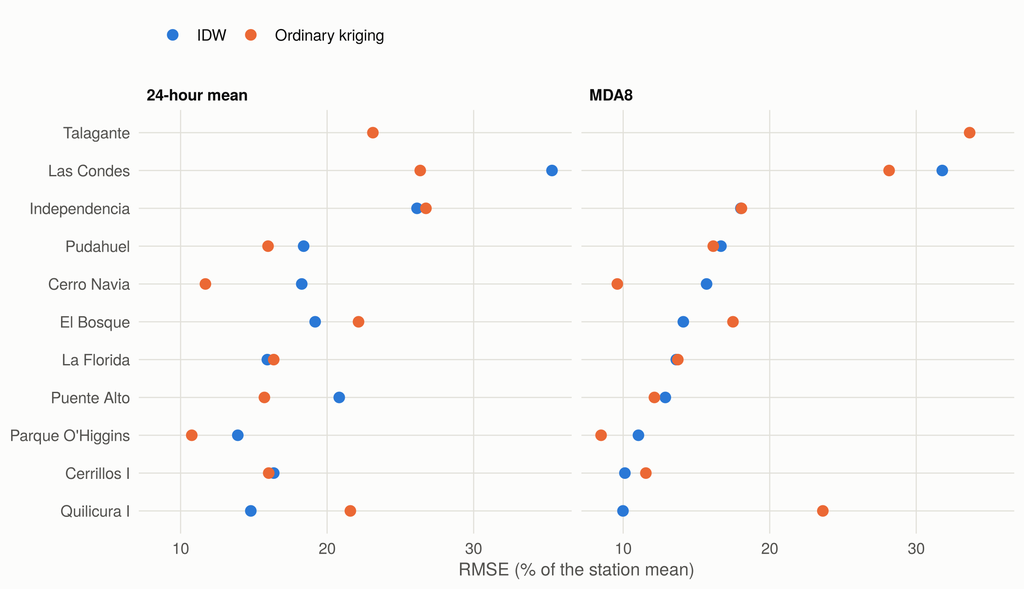

Figure 4: Cross-validation error by station: RMSE as a percentage of the station mean.

```r
station_plot <- copy(loso_station)[, `:=`(metric = metric_label[metric], method = method_label[method])]
order_station <- station_plot[metric == "MDA8" & method == "IDW"][order(nrmse_pct), station]
ggplot(station_plot, aes(nrmse_pct, factor(station, levels = order_station), colour = method)) +
  geom_point(size = 2.4) +
  facet_wrap(~metric) +
  scale_colour_manual(values = colour_method) +
  labs(x = "RMSE (% of the station mean)", y = NULL, colour = NULL)
```

```r
kableExtra::scroll_box(
  kableExtra::kable_styling(
    kable(station_plot[order(metric, station, method),
                       .(metric, station, method, n, mean_observed, bias, rmse, pearson_r, r2)],
          format = "html", digits = c(0, 0, 0, 0, 1, 2, 2, 3, 3), format.args = list(big.mark = ","),
          col.names = c("Metric", "Station", "Method", "Station-days", "Observed mean (ppb)",
                        "Bias (ppb)", "RMSE (ppb)", "Pearson r", "R²")),
    bootstrap_options = c("striped", "condensed"), font_size = 12),
  height = "380px"
)
```

Table 5: Cross-validation by station.

| Metric | Station | Method | Station-days | Observed mean (ppb) | Bias (ppb) | RMSE (ppb) | Pearson r | R² |
| --- | --- | --- | --- | --- | --- | --- | --- | --- |
| 24-hour mean | Cerrillos I | IDW | 1,211 | 22.1 | -2.30 | 3.62 | 0.836 | 0.493 |
| 24-hour mean | Cerrillos I | Ordinary kriging | 1,208 | 22.1 | -1.69 | 3.54 | 0.795 | 0.512 |
| 24-hour mean | Cerro Navia | IDW | 1,704 | 20.8 | -1.18 | 3.79 | 0.728 | 0.423 |
| 24-hour mean | Cerro Navia | Ordinary kriging | 1,702 | 20.8 | -0.26 | 2.43 | 0.878 | 0.763 |
| 24-hour mean | El Bosque | IDW | 1,747 | 18.6 | 2.55 | 3.57 | 0.859 | 0.410 |
| 24-hour mean | El Bosque | Ordinary kriging | 1,746 | 18.6 | 3.08 | 4.12 | 0.841 | 0.215 |
| 24-hour mean | Independencia | IDW | 1,681 | 17.9 | 3.30 | 4.69 | 0.771 | 0.123 |
| 24-hour mean | Independencia | Ordinary kriging | 1,677 | 17.9 | 3.43 | 4.79 | 0.766 | 0.082 |
| 24-hour mean | La Florida | IDW | 1,792 | 19.8 | 0.81 | 3.16 | 0.832 | 0.670 |
| 24-hour mean | La Florida | Ordinary kriging | 1,792 | 19.8 | 1.13 | 3.25 | 0.833 | 0.652 |
| 24-hour mean | Las Condes | IDW | 1,634 | 25.5 | -7.62 | 9.03 | 0.735 | -0.602 |
| 24-hour mean | Las Condes | Ordinary kriging | 1,759 | 25.7 | -5.37 | 6.77 | 0.859 | 0.122 |
| 24-hour mean | Parque O'Higgins | IDW | 1,627 | 21.3 | -1.84 | 2.96 | 0.881 | 0.634 |
| 24-hour mean | Parque O'Higgins | Ordinary kriging | 1,624 | 21.3 | -0.79 | 2.29 | 0.899 | 0.781 |
| 24-hour mean | Pudahuel | IDW | 1,595 | 19.5 | 1.24 | 3.59 | 0.751 | 0.438 |
| 24-hour mean | Pudahuel | Ordinary kriging | 1,595 | 19.5 | 1.13 | 3.12 | 0.811 | 0.576 |
| 24-hour mean | Puente Alto | IDW | 1,675 | 22.9 | -3.73 | 4.77 | 0.836 | 0.218 |
| 24-hour mean | Puente Alto | Ordinary kriging | 1,672 | 22.9 | -2.31 | 3.60 | 0.859 | 0.554 |
| 24-hour mean | Quilicura I | IDW | 1,091 | 21.0 | -1.18 | 3.11 | 0.843 | 0.660 |
| 24-hour mean | Quilicura I | Ordinary kriging | 1,091 | 21.0 | -1.73 | 4.54 | 0.679 | 0.277 |
| 24-hour mean | Talagante | IDW | 0 |  |  |  |  |  |
| 24-hour mean | Talagante | Ordinary kriging | 1,594 | 18.6 | 2.19 | 4.31 | 0.685 | 0.100 |
| MDA8 | Cerrillos I | IDW | 1,196 | 41.6 | -1.69 | 4.21 | 0.929 | 0.837 |
| MDA8 | Cerrillos I | Ordinary kriging | 1,193 | 41.6 | -0.98 | 4.81 | 0.893 | 0.787 |
| MDA8 | Cerro Navia | IDW | 1,696 | 40.1 | -1.67 | 6.29 | 0.806 | 0.591 |
| MDA8 | Cerro Navia | Ordinary kriging | 1,693 | 40.1 | 0.75 | 3.85 | 0.926 | 0.847 |
| MDA8 | El Bosque | IDW | 1,716 | 38.1 | 4.15 | 5.38 | 0.937 | 0.679 |
| MDA8 | El Bosque | Ordinary kriging | 1,715 | 38.1 | 4.83 | 6.67 | 0.897 | 0.506 |
| MDA8 | Independencia | IDW | 1,630 | 38.4 | 3.24 | 6.93 | 0.820 | 0.569 |
| MDA8 | Independencia | Ordinary kriging | 1,622 | 38.4 | 3.62 | 6.94 | 0.832 | 0.568 |
| MDA8 | La Florida | IDW | 1,769 | 42.6 | -1.22 | 5.80 | 0.877 | 0.756 |
| MDA8 | La Florida | Ordinary kriging | 1,768 | 42.6 | -1.29 | 5.84 | 0.876 | 0.752 |
| MDA8 | Las Condes | IDW | 1,568 | 53.1 | -14.62 | 16.86 | 0.779 | -0.587 |
| MDA8 | Las Condes | Ordinary kriging | 1,737 | 53.4 | -13.26 | 15.02 | 0.877 | -0.219 |
| MDA8 | Parque O'Higgins | IDW | 1,602 | 43.0 | -3.21 | 4.74 | 0.937 | 0.775 |
| MDA8 | Parque O'Higgins | Ordinary kriging | 1,596 | 43.0 | -2.04 | 3.65 | 0.954 | 0.867 |
| MDA8 | Pudahuel | IDW | 1,573 | 37.9 | 2.27 | 6.32 | 0.806 | 0.547 |
| MDA8 | Pudahuel | Ordinary kriging | 1,573 | 37.9 | 2.86 | 6.12 | 0.838 | 0.575 |
| MDA8 | Puente Alto | IDW | 1,659 | 44.4 | -3.93 | 5.72 | 0.918 | 0.676 |
| MDA8 | Puente Alto | Ordinary kriging | 1,657 | 44.4 | -3.34 | 5.39 | 0.908 | 0.712 |
| MDA8 | Quilicura I | IDW | 1,082 | 39.5 | -0.11 | 3.95 | 0.919 | 0.843 |
| MDA8 | Quilicura I | Ordinary kriging | 1,082 | 39.5 | -2.46 | 9.34 | 0.682 | 0.122 |
| MDA8 | Talagante | IDW | 0 |  |  |  |  |  |
| MDA8 | Talagante | Ordinary kriging | 1,559 | 32.8 | 9.01 | 11.02 | 0.775 | -0.553 |

### 3.1 High-ozone days

The analysis classifies days as high ozone against a percentile of each place. The same is done here with the predictions: a station-day is predicted high when the prediction exceeds the percentile of the predictions at that station.

```r
high_table <- copy(loso_high)[, `:=`(metric = metric_label[metric], method = method_label[method])]
kable(high_table[order(metric, percentile, method),
                 .(metric, percentile = paste0("> P", percentile), method, n,
                   sensitivity = 100 * sensitivity, specificity = 100 * specificity,
                   agreement = 100 * agreement, kappa)],
      digits = c(0, 0, 0, 0, 1, 1, 1, 2), format.args = list(big.mark = ","),
      col.names = c("Metric", "Cut-off", "Method", "Station-days", "Sensitivity (%)",
                    "Specificity (%)", "Agreement (%)", "Kappa"))
```

Table 6: High-ozone days: predicted against observed classification at the station left out.

| Metric | Cut-off | Method | Station-days | Sensitivity (%) | Specificity (%) | Agreement (%) | Kappa |
| --- | --- | --- | --- | --- | --- | --- | --- |
| 24-hour mean | > P50 | IDW | 15,757 | 81.0 | 81.0 | 81.0 | 0.62 |
| 24-hour mean | > P50 | Ordinary kriging | 17,460 | 81.5 | 81.5 | 81.5 | 0.63 |
| 24-hour mean | > P75 | IDW | 15,757 | 68.9 | 89.6 | 84.4 | 0.58 |
| 24-hour mean | > P75 | Ordinary kriging | 17,460 | 69.0 | 89.7 | 84.5 | 0.59 |
| 24-hour mean | > P90 | IDW | 15,757 | 58.5 | 95.4 | 91.7 | 0.54 |
| 24-hour mean | > P90 | Ordinary kriging | 17,460 | 59.3 | 95.5 | 91.8 | 0.55 |
| MDA8 | > P50 | IDW | 15,491 | 84.9 | 84.7 | 84.8 | 0.70 |
| MDA8 | > P50 | Ordinary kriging | 17,195 | 85.0 | 84.8 | 84.9 | 0.70 |
| MDA8 | > P75 | IDW | 15,491 | 74.8 | 91.6 | 87.4 | 0.66 |
| MDA8 | > P75 | Ordinary kriging | 17,195 | 74.4 | 91.4 | 87.2 | 0.66 |
| MDA8 | > P90 | IDW | 15,491 | 65.3 | 96.1 | 93.0 | 0.61 |
| MDA8 | > P90 | Ordinary kriging | 17,195 | 63.5 | 95.9 | 92.7 | 0.59 |

## 4 C. Delivered and rebuilt municipal series

Script 12 interpolates the validated station values to the 33 municipalities with the same model: `o3obs` is the 24-hour mean and `o3mda8` the daily maximum 8-hour mean.

First, a reproduction test. On the days when every station value of the author’s series equals the validated 24-hour mean, the two municipal series have the same inputs and should coincide if this project runs the same interpolation.

```r
reproduction <- read_table("validation_reproduction.csv")
kable(reproduction[, .(method = method_label[method], days, municipality_days, within_0.001_ppb_pct,
                       median_abs_difference, max_abs_difference)],
      digits = c(0, 0, 0, 1, 6, 4), format.args = list(big.mark = ","),
      col.names = c("Method", "Days", "Municipality-days", "Within 0.001 ppb (%)",
                    "Median absolute difference (ppb)", "Largest absolute difference (ppb)"))
```

Table 7: Rebuilt against delivered municipal ozone on the warm-season days with identical station inputs.

| Method | Days | Municipality-days | Within 0.001 ppb (%) | Median absolute difference (ppb) | Largest absolute difference (ppb) |
| --- | --- | --- | --- | --- | --- |
| IDW | 420 | 13,860 | 100.0 | 5e-06 | 0.0001 |
| Ordinary kriging | 420 | 13,860 | 98.8 | 2e-06 | 0.5174 |

With the same inputs this project returns the delivered values: all of the IDW values and nearly all of the kriging values agree to the third decimal (the daily variogram fit makes kriging sensitive to the last digits of its inputs). The differences shown in the rest of this section therefore come from the station inputs.

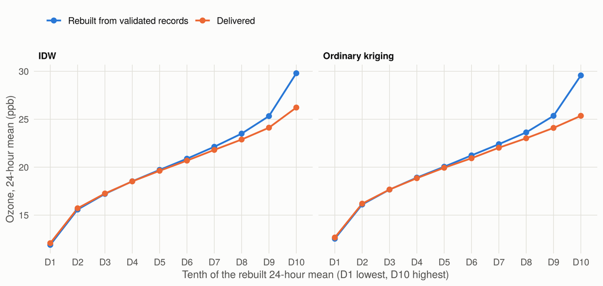

Figure 5: Delivered against rebuilt 24-hour mean by tenths of the rebuilt value, municipality-days of the warm seasons 2009-2020.

```r
ml <- melt(municipal_level[, .(method = method_label[method], level,
                               `Rebuilt from validated records` = rebuilt_mean24,
                               `Delivered` = delivered_mean24)],
           id.vars = c("method", "level"), variable.name = "series", value.name = "ozone")
ml[, level := factor(level, levels = paste0("D", 1:10))]
ggplot(ml, aes(level, ozone, colour = series, group = series)) +
  geom_line(linewidth = 0.8) +
  geom_point(size = 2) +
  facet_wrap(~method) +
  scale_colour_manual(values = c("Rebuilt from validated records" = "#2a78d6", "Delivered" = "#eb6834")) +
  labs(x = "Tenth of the rebuilt 24-hour mean (D1 lowest, D10 highest)",
       y = "Ozone, 24-hour mean (ppb)", colour = NULL)
```

```r
kable(municipal_level[, .(method = method_label[method], level, municipality_days, rebuilt_mean24,
                          delivered_mean24, difference, rebuilt_mda8)],
      digits = 1, format.args = list(big.mark = ","),
      col.names = c("Method", "Tenth", "Municipality-days", "Rebuilt 24-hour mean (ppb)",
                    "Delivered (ppb)", "Difference (ppb)", "Rebuilt MDA8 (ppb)"))
```

Table 8: Values behind the figure, with the rebuilt MDA8 of the same municipality-days.

| Method | Tenth | Municipality-days | Rebuilt 24-hour mean (ppb) | Delivered (ppb) | Difference (ppb) | Rebuilt MDA8 (ppb) |
| --- | --- | --- | --- | --- | --- | --- |
| IDW | D1 | 5,983 | 11.9 | 12.1 | 0.2 | 24.8 |
| IDW | D2 | 5,982 | 15.6 | 15.7 | 0.1 | 32.1 |
| IDW | D3 | 5,982 | 17.2 | 17.3 | 0.0 | 35.1 |
| IDW | D4 | 5,982 | 18.5 | 18.5 | 0.0 | 37.8 |
| IDW | D5 | 5,983 | 19.7 | 19.6 | -0.1 | 40.1 |
| IDW | D6 | 5,982 | 20.9 | 20.7 | -0.2 | 42.5 |
| IDW | D7 | 5,982 | 22.1 | 21.8 | -0.3 | 44.8 |
| IDW | D8 | 5,982 | 23.5 | 22.9 | -0.6 | 47.4 |
| IDW | D9 | 5,982 | 25.3 | 24.1 | -1.2 | 51.0 |
| IDW | D10 | 5,983 | 29.8 | 26.2 | -3.6 | 58.6 |
| Ordinary kriging | D1 | 5,982 | 12.5 | 12.7 | 0.1 | 25.7 |
| Ordinary kriging | D2 | 5,982 | 16.1 | 16.2 | 0.1 | 32.8 |
| Ordinary kriging | D3 | 5,982 | 17.7 | 17.7 | 0.0 | 35.5 |
| Ordinary kriging | D4 | 5,982 | 18.9 | 18.9 | -0.1 | 37.7 |
| Ordinary kriging | D5 | 5,982 | 20.0 | 19.9 | -0.1 | 40.6 |
| Ordinary kriging | D6 | 5,981 | 21.2 | 20.9 | -0.3 | 42.9 |
| Ordinary kriging | D7 | 5,982 | 22.4 | 22.0 | -0.4 | 45.0 |
| Ordinary kriging | D8 | 5,982 | 23.6 | 23.0 | -0.6 | 47.2 |
| Ordinary kriging | D9 | 5,982 | 25.4 | 24.1 | -1.3 | 50.6 |
| Ordinary kriging | D10 | 5,982 | 29.6 | 25.4 | -4.2 | 58.1 |

### 4.1 Does the choice of series change who is exposed?

```r
series_label <- c(o3 = "Delivered 24-hour mean", o3obs = "Rebuilt 24-hour mean", o3mda8 = "Rebuilt MDA8")
flags <- copy(municipal_flags)[, `:=`(reference = series_label[reference], compared = series_label[compared],
                                      method = method_label[method])]
kable(flags[, .(reference, compared, method, percentile = paste0("> P", percentile), pearson_r,
                sensitivity = 100 * sensitivity, specificity = 100 * specificity,
                agreement = 100 * agreement, kappa)],
      digits = c(0, 0, 0, 0, 2, 1, 1, 1, 2),
      col.names = c("Reference", "Compared", "Method", "Cut-off", "Pearson r", "Sensitivity (%)",
                    "Specificity (%)", "Agreement (%)", "Kappa"))
```

Table 9: Agreement of the high-ozone flags between series, municipality-days of the warm seasons 2009-2020. Sensitivity and specificity take the first series as reference.

| Reference | Compared | Method | Cut-off | Pearson r | Sensitivity (%) | Specificity (%) | Agreement (%) | Kappa |
| --- | --- | --- | --- | --- | --- | --- | --- | --- |
| Rebuilt 24-hour mean | Delivered 24-hour mean | IDW | > P50 | 0.92 | 94.3 | 94.4 | 94.4 | 0.89 |
| Rebuilt 24-hour mean | Delivered 24-hour mean | IDW | > P75 | 0.92 | 82.5 | 94.2 | 91.3 | 0.77 |
| Rebuilt 24-hour mean | Delivered 24-hour mean | IDW | > P90 | 0.92 | 63.5 | 95.9 | 92.7 | 0.59 |
| Rebuilt 24-hour mean | Delivered 24-hour mean | Ordinary kriging | > P50 | 0.84 | 91.1 | 91.2 | 91.1 | 0.82 |
| Rebuilt 24-hour mean | Delivered 24-hour mean | Ordinary kriging | > P75 | 0.84 | 78.2 | 92.7 | 89.1 | 0.71 |
| Rebuilt 24-hour mean | Delivered 24-hour mean | Ordinary kriging | > P90 | 0.84 | 58.7 | 95.4 | 91.7 | 0.54 |
| Rebuilt MDA8 | Delivered 24-hour mean | IDW | > P50 | 0.82 | 84.6 | 84.7 | 84.6 | 0.69 |
| Rebuilt MDA8 | Delivered 24-hour mean | IDW | > P75 | 0.82 | 67.3 | 89.1 | 83.7 | 0.56 |
| Rebuilt MDA8 | Delivered 24-hour mean | IDW | > P90 | 0.82 | 42.3 | 93.6 | 88.4 | 0.36 |
| Rebuilt MDA8 | Delivered 24-hour mean | Ordinary kriging | > P50 | 0.74 | 81.8 | 82.0 | 81.9 | 0.64 |
| Rebuilt MDA8 | Delivered 24-hour mean | Ordinary kriging | > P75 | 0.74 | 64.6 | 88.2 | 82.3 | 0.53 |
| Rebuilt MDA8 | Delivered 24-hour mean | Ordinary kriging | > P90 | 0.74 | 41.2 | 93.4 | 88.2 | 0.35 |
| Rebuilt MDA8 | Rebuilt 24-hour mean | IDW | > P50 | 0.91 | 87.5 | 87.6 | 87.6 | 0.75 |
| Rebuilt MDA8 | Rebuilt 24-hour mean | IDW | > P75 | 0.91 | 79.0 | 93.0 | 89.5 | 0.72 |
| Rebuilt MDA8 | Rebuilt 24-hour mean | IDW | > P90 | 0.91 | 72.9 | 97.0 | 94.6 | 0.70 |
| Rebuilt MDA8 | Rebuilt 24-hour mean | Ordinary kriging | > P50 | 0.90 | 86.8 | 86.9 | 86.8 | 0.74 |
| Rebuilt MDA8 | Rebuilt 24-hour mean | Ordinary kriging | > P75 | 0.90 | 78.0 | 92.7 | 89.1 | 0.71 |
| Rebuilt MDA8 | Rebuilt 24-hour mean | Ordinary kriging | > P90 | 0.90 | 72.8 | 97.0 | 94.5 | 0.70 |

## 5 An independent source: the CAMS reanalysis

No satellite measures ozone at the surface with the resolution of a city: the ozone column seen from space is dominated by the stratosphere. The closest independent source is a reanalysis that assimilates the satellite retrievals into a chemistry model. CAMS EAC4 has cells of 0.75 degrees, so the 33 municipalities fall in two cells and the comparison says nothing about differences between municipalities. What it can check is whether the day-to-day course of ozone over the city in the station-based series is also seen by a source that does not use the monitors.

```r
cams_series <- c(o3_idw = "Delivered 24-hour mean, IDW", o3_ok = "Delivered 24-hour mean, kriging",
                 o3obs_idw = "Rebuilt 24-hour mean, IDW", o3obs_ok = "Rebuilt 24-hour mean, kriging",
                 o3mda8_idw = "Rebuilt MDA8, IDW", o3mda8_ok = "Rebuilt MDA8, kriging")
cams_table <- copy(cams)[, `:=`(series = cams_series[series],
                                cams = fifelse(cams == "cams_mean24", "Daily mean", "Afternoon (15 and 18 h)"))]
kable(cams_table, digits = c(0, 0, 0, 1, 1, 2, 2), format.args = list(big.mark = ","),
      col.names = c("Station-based series", "CAMS value", "Days", "Series mean (ppb)",
                    "CAMS mean (ppb)", "Correlation, daily values", "Correlation, anomalies"))
```

Table 10: City-wide daily ozone against CAMS EAC4, warm seasons 2009-2020. Anomalies are deviations from the mean of each calendar month.

| Station-based series | CAMS value | Days | Series mean (ppb) | CAMS mean (ppb) | Correlation, daily values | Correlation, anomalies |
| --- | --- | --- | --- | --- | --- | --- |
| Delivered 24-hour mean, IDW | Daily mean | 1,814 | 19.9 | 35.6 | 0.33 | 0.17 |
| Delivered 24-hour mean, kriging | Daily mean | 1,814 | 20.1 | 35.6 | 0.32 | 0.17 |
| Rebuilt 24-hour mean, IDW | Daily mean | 1,812 | 20.5 | 35.6 | 0.36 | 0.23 |
| Rebuilt 24-hour mean, kriging | Daily mean | 1,812 | 20.7 | 35.6 | 0.37 | 0.24 |
| Rebuilt MDA8, IDW | Afternoon (15 and 18 h) | 1,812 | 41.4 | 59.1 | 0.42 | 0.41 |
| Rebuilt MDA8, kriging | Afternoon (15 and 18 h) | 1,811 | 41.6 | 59.1 | 0.44 | 0.42 |

CAMS is a weak reference for surface ozone in a basin that one of its cells covers almost entirely, mountains included: its values are much higher than the monitors and the correlations are modest. Within those limits, the series rebuilt from validated records follow it more closely than the delivered series, and the MDA8 more closely than the 24-hour mean.

## 6 What this means for the analysis

```r
common_wide <- dcast(loso_common, metric ~ method, value.var = c("rmse", "r2"))
mda8_flags <- municipal_flags[reference == "o3mda8" & compared == "o3" & method == "idw"]
coverage <- loso[method == "ok", .(metric, interval_coverage_pct)]
las_condes <- loso_station[station == "Las Condes" & metric == "mda8" & method == "ok"]
top_municipal <- municipal_level[method == "idw" & level == "D10"]
```

1. **The delivered series understates the days with most ozone.** Its station inputs are 6.5 ppb below the measurements on the highest tenth of station-days, and its municipal values are 3.6 ppb below the rebuilt ones on the highest tenth of municipality-days. A study of high-ozone days and of their interaction with heat should not use inputs trimmed at the 99th percentile.
2. **Station-days without a validated measurement are estimates.** In the delivered series 6.5% of the warm-season station-days have no validated daily mean; the Independencia monitor, which failed in 2016, is carried by imputed values for most of that year. The rebuilt series use validated records only.
3. **The metric matters.** The plan names the MDA8; the delivered series is a 24-hour mean. Among the municipality-days above the 75th percentile of MDA8, the delivered 24-hour mean flags 67% as high ozone (kappa 0.56).
4. **Interpolation method.** On the same station-days ordinary kriging has the lower cross-validation error for both metrics: RMSE 4.00 against 4.61 ppb for the 24-hour mean and 7.35 against 7.59 ppb for the MDA8. The difference is clear for the 24-hour mean and small for the MDA8. The kriging intervals contain the left-out observation 75% of the time for the MDA8 and 84% of the time for the 24-hour mean, against a nominal 95%, so they should not be read as measurement uncertainty. The working value of the configuration is still IDW; this result argues for kriging and the choice is open.
5. **What interpolation cannot fix.** Nine to eleven monitors describe 33 municipalities, and the error is far from uniform. Las Condes, the station with most ozone, cannot be predicted from the others (bias -13.3 ppb when it is left out): the eastern municipalities depend on that single monitor. The cross-validation error is the error at a monitored site when its own monitor is ignored; it is the best available estimate of the error in municipalities without a monitor, not a guarantee.

The exposure dataset keeps the three series (`o3`, `o3obs`, `o3mda8`) so that the choice can be made by the principal investigator and its effect shown as a sensitivity analysis. The working value in the configuration is still the delivered series.